# imports

```python
import codecs
import csv
import spacy
import time
import operator
import timeit
import nltk
from nltk import word_tokenize
import random as rd
import numpy as np
import matplotlib.pyplot as plt
```

# Assignment 1

## Guidelines

> Remember to add an explanation of what you do using markdown, and to comment your code. Please *be brief*.

> If you re-use a substantial portion of code you find online, e.g on Stackoverflow, you need to add a link to it and make the borrowing explicit. The same applies of you take it and modify it, even substantially. There is nothing bad in doing that, providing you are acknowledging it and make it clear you know what you're doing.

> Make sure your notebooks have been run when you sumit, as I won't run them myself. Submit both the `.ipynb` file along with an `.html` export of the same. Submit all necessary auxilliary files as well. Please compress your submission into a `.zip` archive. Only `.zip` files can be submitted.

## Grading policy

> As follows:
> - 70 points for correctly completing the assignment.
> - 20 points for appropriately writing and organizing your code in terms of structure, readibility (also by humans), comments and minimal documentation. It is important to be concise but also to explain what you did and why, when not obvious.
> - 10 points for doing something extra, e.g., if you go beyond expectations (overall or on something specific). Some ideas for extras might be mentioned in the exercises, or you can come up with your own. You don't need to do them all to get the bonus. The sum of points is 90, doing (some of) the extras can bring you to 100, so the extras are not necessary to get an A.

**The AUC code of conduct applies to this assignment: please only submit your own work.**

# Warm up (25 points)

## Question 1 (2 points)

Explain why `list1` and `list2` behave differently when they are passed to the `append_to_nested_list()` function.

```python
def append_to_nested_list(a_list):
    a_list[0].append("Python")
    return a_list

list1 = [[], [], []]
list2 = [[]] * 3

print(append_to_nested_list(list1))
print(append_to_nested_list(list2))
```

```
[['Python'], [], []]
[['Python'], ['Python'], ['Python']]
```

### Explanation

Because they are stored in different memory locations. List1 contains 3 seperate entities with different id's, whereas list2 contains 1 entity thrice.

This difference between the lists can be shown using the id function:

```python
def append_to_nested_list(a_list):
    a_list[0].append("Python")
    return a_list

list1 = [[], [], []]
list2 = [[]] * 3

#ID's are not equal for list1, but they are equal for list2
print(id(list1[0]) == id(list1[1]))
print(id(list2[0]) == id(list2[1]))
```

```
False
True
```

Therefore, when the original empty list is modified, this will cause list2's other entries to change with it.

List1's entries however are seperate memory entities, and therefore the second 2 will not change when the first one does

## Question 2 (3 points)

Write a function that counts the frequency of all the [palindrome](https://en.wikipedia.org/wiki/Palindrome) words in a text file and test it on `data/melville-md.txt`.

Ensure that the words are treated case-insensitive.

```python
corpus = "data/melville-md.txt"
dict = {}

def palindrome(corpus):
    #open the file
    file = open(corpus, "r", encoding='utf-8')
    for line in file:
        #read each word seperately
        for word in line.split():
            #case insensitive
            word = word.lower()
            #limiting to palindromes and alphabet
            if (word == word[::-1]) and word.isalpha():
                #adding palindromes to the dict
                if word not in dict:
                    dict[word] = 1
                elif word in dict:
                    dict[word] += 1
    for i in dict:
        print("The Palindrome:", i, "is contained", dict[i], "times")


palindrome(corpus)
```

```
The Palindrome: a is contained 4666 times
The Palindrome: l is contained 1 times
The Palindrome: i is contained 1724 times
The Palindrome: eye is contained 45 times
The Palindrome: did is contained 231 times
The Palindrome: ere is contained 76 times
The Palindrome: redder is contained 1 times
The Palindrome: eve is contained 2 times
The Palindrome: sees is contained 4 times
The Palindrome: o is contained 25 times
The Palindrome: peep is contained 7 times
The Palindrome: dad is contained 1 times
The Palindrome: x is contained 1 times
The Palindrome: dood is contained 2 times
The Palindrome: level is contained 21 times
The Palindrome: deed is contained 3 times
The Palindrome: pip is contained 25 times
The Palindrome: noon is contained 5 times
The Palindrome: deified is contained 3 times
The Palindrome: refer is contained 3 times
The Palindrome: gag is contained 2 times
The Palindrome: bob is contained 1 times
The Palindrome: pop is contained 1 times
The Palindrome: non is contained 2 times
```

## Question 3 (3 points)

Rewrite the following code such that:

- the sequence of fruit names are randomly presented (without replacement). Use a function in the [random](https://docs.python.org/3.7/library/random.html) module for this.
- the article "an" is used when a fruit name begins with a vowel.

```python
available_fruit = ['apple', 'apricot', 'avocado', 'banana', 'bilberry', 'blackberry', 'blackcurrant', 'blueberry', 'boysenberry', 'currant', 'cherry', 'cherimoya', 'cloudberry', 'coconut', 'cranberry', 'cucumber', 'damson', 'date', 'dragonfruit', 'durian', 'elderberry', 'feijoa', 'fig', 'gooseberry', 'grape', 'raisin', 'grapefruit', 'guava', 'honeyberry', 'huckleberry', 'jabuticaba', 'jackfruit', 'jambul', 'jujube', 'kiwano', 'kiwifruit', 'kumquat', 'lemon', 'lime', 'loquat', 'longan', 'lychee', 'mango', 'mangosteen', 'marionberry', 'melon', 'cantaloupe', 'honeydew', 'watermelon', 'mulberry', 'nectarine', 'nance', 'orange', 'clementine', 'mandarine', 'tangerine', 'papaya', 'passionfruit', 'peach', 'pear', 'persimmon', 'physalis', 'plantain', 'plum', 'prune', 'pineapple', 'plumcot', 'pomegranate', 'pomelo', 'quince', 'raspberry', 'salmonberry', 'rambutan', 'redcurrant', 'salak', 'satsuma', 'soursop', 'strawberry', 'tamarillo', 'tamarind', 'yuzu']
vowels = ['a', 'e', 'i','o','u']

def sequence(available_fruit):
    #shuffle the list
    rd.shuffle(available_fruit)
    for fruit in available_fruit:
        #check if it starts with a vowel to add an
        if fruit[0] in vowels:
            print("We have an " + fruit)
        #otherwise just print
        else:
            print("We have a " + fruit)

sequence(available_fruit)
```

```
We have an apricot
We have a tangerine
We have a coconut
We have a nance
We have a persimmon
We have a huckleberry
We have a bilberry
We have a clementine
We have a cantaloupe
We have a melon
We have a mulberry
We have a passionfruit
We have a blackberry
We have an elderberry
We have a rambutan
We have a plantain
We have a peach
We have a soursop
We have a damson
We have a grape
We have a mangosteen
We have a cucumber
We have a redcurrant
We have an orange
We have a raspberry
We have a cloudberry
We have a pomegranate
We have a raisin
We have a pomelo
We have a cranberry
We have a yuzu
We have a physalis
We have a dragonfruit
We have a grapefruit
We have a jackfruit
We have a jambul
We have a papaya
We have a prune
We have a cherimoya
We have a tamarind
```

[output cut: 26 more lines]

```
We have a lemon
We have a quince
We have a honeyberry
We have a loquat
We have a salmonberry
We have a tamarillo
We have a fig
We have a gooseberry
We have a honeydew
We have an avocado
We have a salak
We have a cherry
We have a blueberry
We have a banana
We have a nectarine
```

## Question 4 (7 points)

The following code has been written to extract all the distinct consonants sequences in a text, where each sequence is obtained by stripping the vowels from a case-insensitive token (and a token is a sequence of characters separated by whitespaces).

It works by reading an input file line by line, filtering out the vowels from each (case insensitive) token and saving each pattern of consonants in a set.

Unfortunately, the method is quite slow. Can you find a way to speed it up? Please use the `timeit` method to show improvements from the provided version. **Possible extra:** find more than one way to speed it up.

```python
import codecs
```

```python
%%timeit
stripped_words = set()
with codecs.open("data/melville-md.txt", "r", encoding="utf8") as infile:
    for line in infile:
        splLine= line.split()
        for word in splLine:
            consonant_seq = "".join([c for c in word.lower() if c not in ["a", "e", "i", "o", "u"]])
            stripped_words.add(consonant_seq)
```

```
607 ms ± 10.2 ms per loop (mean ± std. dev. of 7 runs, 1 loop each)
```

Simply taking the use of codecs out of the code already substantially lowers its runtime:

```python
%%timeit
stripped_words = set()
with open("data/melville-md.txt", "r", encoding="utf8") as infile:
    for line in infile:
        splLine= line.split()
        for word in splLine:
            consonant_seq = "".join([c for c in word.lower() if c not in ["a", "e", "i", "o", "u"]])
            stripped_words.add(consonant_seq)
```

```
414 ms ± 17.2 ms per loop (mean ± std. dev. of 7 runs, 1 loop each)
```

## Question 5 (10 points)

Please use the frequencies in `late_arrival_causes` to create a duplicate of the plot below, as close as possible. This is called a Pareto chart.

Note: the line plot above the bars shows the cumulative frequency.

**Possible extra:** suggest, motivate and implement an alternative visualization for the same data.

[figure not shown]

```python
late_arrival_causes = {"Child Care" : 44, "Emergency" : 7, "Overslept" : 11, "Traffic" : 56, "Transp." : 27, "Weather" : 20}
```

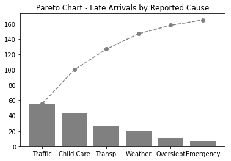

```python
# With some help from:
#https://stackoverflow.com/questions/613183/how-do-i-sort-a-dictionary-by-value
#https://www.geeksforgeeks.org/graph-plotting-in-python-set-1/

dic = {"Child Care" : 44, "Emergency" : 7, "Overslept" : 11, "Traffic" : 56, "Transp." : 27, "Weather" : 20}
y = []
#Isolating and sorting the keys
x = sorted(dic, key=dic.get)
x.reverse()
#Same for values
for key in x:
    y.append(dic[key])

#calculating cumulative
cum = []
counter = 0
for value in y:
    counter += value
    cum.append(counter)

#creating the plot
plt.plot(x,cum, color = 'gray', linestyle = 'dashed', marker = 'o')
plt.bar(x,y, color = 'gray',)
plt.title('Pareto Chart - Late Arrivals by Reported Cause')

plt.show()
```

# Preprocessing pipelines (40 points)

## Question 6 (25 points)

- Download a 19th-century edition (or earlier, but not later!) of a book you like from the [Internet Archive](https://archive.org) in `.txt` format. For example, [Frankenstein](https://archive.org/details/ghostseer01schiuoft/page/n6). Add the link to the edition you used to your answer, as well as the `.txt` file to your submission.
- Write code that:
  1. Reads the text in memory.
  2. Pre-processes the text with a tokenizer from [NLTK](https://www.nltk.org/api/nltk.tokenize.html) (remember to motivate your choice).
  3. Filter out words that consist of strictly less than 4 alphabetic characters.
  4. Counts the frequencies of all the words in the corpus (words should be counted case-insensitive).
  5. Writes each word-frequency pair to a csv file (from most frequent to rarest).

*Briefly* comment on your results, especially looking at very frequent and very unfrequent words. What is problematic about these old editions? Can you find some limitations of the tokenizer in use, and think about how you would improve on it?

**Possible extra:** plot the relative frequency of the top N words (e.g., use the Pareto chart you did above, or another suitable plot) and discuss whether the distribution might follow the [Zipf's law](https://en.wikipedia.org/wiki/Zipf%27s_law).

**Possible extra:** add lemmatization or stemming and part-of-speech tagging.

```python
#with some help from: https://medium.com/@datamonsters/text-preprocessing-in-python-steps-tools-and-examples-bf025f872908
# and https://stackabuse.com/how-to-sort-dictionary-by-value-in-python/
# and https://realpython.com/python-csv/


"""
For this question, I used 'How to Photograph Microscopic Objects' from 1886
found at: https://archive.org/details/howtophotograph00jenngoog
and saved as: data/microscopic.txt
"""
tokens = []
freqs = {}

#open the file
with open("data/microscopic.txt", "r", encoding="utf8") as infile:
    for line in infile:
        #tokenize the file based on individual words, removing punctuation
        tokenline = word_tokenize(line)
        for token in tokenline:
            #remove any token smaller than 4 letters
            if len(token) > 4:
                tokens.append(token.lower())

#count the frequency of each token occurence in a dict
for token in tokens:
    if token not in freqs:
        freqs[token] = 1
    elif token in freqs:
        freqs[token] +=1

#sort the frequency dict
sorted_dict = {}
sorted_keys = reversed(sorted(freqs, key=freqs.get))
for w in sorted_keys:
    sorted_dict[w] = freqs[w]

#Writing the tokens + frequencies to a csv file
with open('data/frequencies.csv', mode='w', encoding = 'utf8') as outfile:
    writer = csv.writer(outfile, delimiter=',')
    #Creating the header
    writer.writerow(['Token','Frequency'])
    #writing from sorteddict
    for pair in sorted_dict:
        writer.writerow([pair,sorted_dict[pair]])
    print("All tokens and frequencies have been written to data/frequencies.csv")
```

```
All tokens and frequencies have been written to data/frequencies.csv
```

### Comments:

The most frequent word in the microscopic.txt corpus is the stopword "which", which could potentially be filtered out along with other words of its kind. Microscopic and Microscope are also found rather high on the frequency list, which makes sense due to the text topic. A problem with these old texts and text recognition is that many words are misspelled. This creates a number of uniteresting tokens in the corpus, which can have many variations and therefore cloud our data. The process could be improved by removing the misspelled words, and potentially also removing stopwords.

## Bonus:

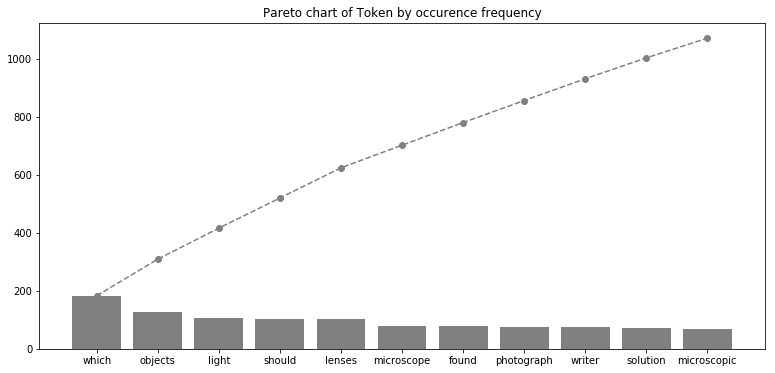

```python
N = 10
counter = 0
x = []
y = []

#Getting the first N tokens and frequencies
for key in sorted_dict:
    if counter > N:
        break
    else:
        x.append(key)
        y.append(sorted_dict[key])
        counter += 1

#Using part of code from question 5 to create a pareto chart:
#calculating cumulative
cum = []
counter = 0
for value in y:
    counter += value
    cum.append(counter)

#creating the plot
plt.figure(figsize=(13, 6))
plt.plot(x,cum, color = 'gray', linestyle = 'dashed', marker = 'o')
plt.bar(x,y, color = 'gray',)
plt.title('Pareto chart of Token by occurence frequency')

plt.show()
```

## Question 7 (15 points)

Do some self-learning: implement the same pipeline of question 6 using [spaCy pipelines](https://spacy.io/usage/processing-pipelines).

```python
#With some help from https://spacy.io/usage/processing-pipelines
#and my own code from question 6
tokens = []

#Load the spacy pipeline
nlp = spacy.load("en_core_web_sm")

#open the file
with open("data/microscopic.txt", "r", encoding="utf8") as infile:
    #implement the pipeline
    for doc in nlp.pipe(infile):
        for token in doc:
            #remove any token smaller than 4 letters
            if len(token) > 4:
                tokens.append(token)

#count the frequency of each token occurence in a dict
for token in tokens:
    if token not in freqs:
        freqs[token] = 1
    elif token in freqs:
        freqs[token] +=1

#sort the frequency dict
sorted_dict = {}
sorted_keys = reversed(sorted(freqs, key=freqs.get))
for w in sorted_keys:
    sorted_dict[w] = freqs[w]

#Writing the tokens + frequencies to a csv file
with open('data/frequenciesSpacy.csv', mode='w', encoding = 'utf8') as outfile:
    writer = csv.writer(outfile, delimiter=',')
    #Creating the header
    writer.writerow(['Token','Frequency'])
    #writing from sorteddict
    for pair in sorted_dict:
        writer.writerow([pair,sorted_dict[pair]])
    print("All tokens and frequencies have been written to data/frequenciesSpacy.csv")
```

```
All tokens and frequencies have been written to data/frequenciesSpacy.csv
```

# Text similarity (25 points)

## Question 8 (25 points)

The **Levenshtein Distance** (see [Wikipedia](https://en.wikipedia.org/wiki/Levenshtein_distance) and J&M, Ch. 2.5) calculates the distance between two strings as the number of deletions, insertions, or substitutions required to transform one into the other. This is also called edit distance. **Write a reasonably efficient function to calculate this metric**.

Examples:

- `levenshtein(" Hello ", "hello")` returns 3 (case sensitive)
- `levenshtein("aeiou", "aeiouuu")` returns 2

Remarks:

- **Important:** a (naive) recursive implementation is going to be very slow, so one way to ensure the function is efficient is by making it *iterative*. That said, there are also ways to speed up a recursive implementation. In the end, how you implement it is up to you, as long as it works.
- The Wikipedia article discusses the difference between a (slow) recursive strategy and a (fast) iterative one.
- Test your function with `%timeit` on two words with a high distance, e.g. "levenshteindistance" vs. "ecnatsidniethsnevel". If your function takes seconds to compute the distance, it's too slow. A moderately fast iterative function finishes in 100-200 ns on my computer.
- This exercise only consists of writing a single function, so the threshold for **code originality** is higher here than in other exercises. The code for this exercise must be your own. If I find the code submitted to this exercise somewhere online (even with small changes like new variable names) it will be graded 0 points. Submitting a slow function that you wrote yourself is better than submitting a fast, but copied function.
- Carefully comment your code in order to explain what your function is doing. **In this case, uncommented code will not be graded at all**.

```python
def levenshtein(str1, str2):
    distance = 0
    #Define which string is longest and which is shortest
    if len(str1) == len(str2):
        lonstr = str1
        shortstr = str2
    elif len(str1) > len(str2):
        lonstr = str1
        shortstr = str2
    elif len(str2) > len(str1):
        lonstr = str2
        shortstr = str1
    #add len() difference to distance
    distance += (len(lonstr) - len(shortstr))
    #adding all str characters to seperate lists
    shortlst = []
    lonlst = []
    for i in range(len(shortstr)):
        shortlst.append(shortstr[i])
    for i in range(len(lonstr)):
        lonlst.append(lonstr[i])
    #adding 1 to distance for each differing letter
    for l in shortlst:
        if l not in lonlst:
            distance += 1
    counter = 0
    #adding anagram distance
    if len(shortlst) == len(lonlst):
        for l in lonlst[:len(shortlst)]:
            if lonlst[counter].lower() != shortlst[counter].lower():
                distance += 1
            counter +=1
    return distance

print(levenshtein(" Hello ", "hello"))
print(levenshtein("aeiou", "aeiouuu"))
print(levenshtein("levenshteindistance","ecnatsidniethsnevel"))
```

```
3
2
16
```

### Timing Performance:

Now, we use the timeit.timeit function to determine how long this function takes to run:

```python
#For this timing, I had a look at https://www.geeksforgeeks.org/timeit-python-examples/
setup = """
def levenshtein(str1, str2):
    distance = 0
    #Define which string is longest and which is shortest
    if len(str1) == len(str2):
        lonstr = str1
        shortstr = str2
    elif len(str1) > len(str2):
        lonstr = str1
        shortstr = str2
    elif len(str2) > len(str1):
        lonstr = str2
        shortstr = str1
    #add len() difference to distance
    distance += (len(lonstr) - len(shortstr))
    #adding all str characters to seperate lists
    shortlst = []
    lonlst = []
    for i in range(len(shortstr)):
        shortlst.append(shortstr[i])
    for i in range(len(lonstr)):
        lonlst.append(lonstr[i])
    #adding 1 to distance for each differing letter
    for l in shortlst:
        if l not in lonlst:
            distance += 1
    counter = 0
    #adding anagram distance
    if len(shortlst) == len(lonlst):
        for l in lonlst[:len(shortlst)]:
            if lonlst[counter].lower() != shortlst[counter].lower():
                distance += 1
            counter +=1
    return distance"""

easy = """
levenshtein(" Hello ", "hello")"""

hard = """
levenshtein("levenshteindistance","ecnatsidniethsnevel")"""

time_taken_easy = timeit.timeit(setup = setup, stmt = easy,
                     number = 1)
time_taken_hard = timeit.timeit(setup = setup, stmt = hard,
                     number = 1)

print("time to calculate distance between  Hello and hello is:", time_taken_easy*1000, "ms")
print("time to calculate distance between levenshteindistance and ecnatsidniethsnevel is:", time_taken_hard*1000, "ms")
```

```
time to calculate distance between  Hello and hello is: 0.0075999999999964984 ms
time to calculate distance between levenshteindistance and ecnatsidniethsnevel is: 0.020499999997980467 ms
```